# Final Project

Vincent Smedile

13 December, 2020

## Introduction and Research Question

Throughout this year, there has been a consierable amount of discoursw surrounding what kind of states and economic systems can handle the pandemic best, especially given the comparatively low amount of deaths and infectios social democracies (such as Iceland and New Zealand) and marxist countries (such as Vietnam and Cuba) have experienced. As a result, it begs the question: Does state’s socioeconomic and political structure (such as socialism, capitalism, the “Nordic Model, or Communism) effect it’s ability to deal with the Coronavirus? And what other factors might cause the disparity we see between nations like the United States and nations like Vietnam? In order to do this, I will be categorizing nations into the following unique state types: Marxist (which would comprise of the four major states still espousing communism; China, Cuba, Laos, and Vietnam), Nordic Model States (which comprises what many academics consider to follow the unique”Nordic Third Way" of high economic freedoms and high social programs and collctive barganing such as Norway, Sweden, Iceland, Denmark, and Finland), Socialist Coalition Governments (which comprises of both dominant party republics and states with parliamentary elected socialist coalitions), and Capitalist countries (which comprises everyone else). To do this, I compared state type and a variable I created called “Covid Response Sucess Rate”, or CRSR, which is a combined measure of a nations infection and death rates, and their total cases and deaths due to COVID. A lower score corresponds to a better COVID response, and is considered to be good. I will be separating the nations into different economic development tiers to ensure that there is no confounding influence of development.

## Data

Below I have loaded the necessary packages for this analysis, including political science packages that will allow me to run preliminary regression analyses on my data.

```r
# Load required packages
library(ggplot2)
library(rio)
library(descr)
library(stargazer)
library(dplyr)
```

### Sources of Data

The Primary source is the [COVID International Dataset](https://github.com/slinnpsu/PLSC309/blob/master/covid_international.csv), which was created by Clayton Webb of the Kansas State Unversity Political Science Department (a partner of my Political Science professor here at Penn State), who complied the dataset using datasets from the [Our World in Data](https://ourworldindata.org/) and [The Quality of Government Institute](https://qog.pol.gu.se/). I specifically obtained it through Dr. Suzanna Linn, a Professor of Political Science here at Penn State (who is currently one of my other instructors). ISO Codes were taken from the [International Organization for Standardization](https://www.iso.org/about-us.html). The secondary source I obtained from the [World Bank](https://data.worldbank.org/indicator/NY.GNP.PCAP.CD). The Covid International Dataset is collected and maintained by Clayton Webb of KSU and the GNI data is collected and maintained by the World Bank.

The COVID International Dataset was collected by Professor Webb for the purposes of analyzing the social and political impacts of COVID-19 on international affairs. Due to his past partnerships with Professor Linn of the Penn State Political Science Department, the PSU Polisci Dept. also uses it for the same purposes and gives it to Polisci students for individual research practice.

My main independent variable of analysis will be the **State_Type** variable, and my main dependent variable of analysis will be the **response_sucess_lev** variable, which corresponds to a nation’s CRSR (COVID Response Sucess Rate)

```r
#Load Data Files
covid_data <- read.csv("covid_international.csv")
gni_data <- read.csv("Income ratings.csv")
```

### Overview of Data

#### Analysis of the Covid International Dataset

```r
str(covid_data)
```

```
'data.frame':   212 obs. of  79 variables:
 $ location                  : Factor w/ 212 levels "Afghanistan",..: 1 2 3 4 5 6 7 8 9 10 ...
 $ iso_code                  : Factor w/ 212 levels "","ABW","AFG",..: 3 6 57 7 4 5 11 9 10 2 ...
 $ continent                 : Factor w/ 7 levels "","Africa","Asia",..: 3 4 2 4 2 5 5 7 3 5 ...
 $ cases                     : int  37596 7380 38583 989 1879 3 93 289087 41663 1102 ...
 $ inf_rate                  : num  170.1 45.6 170.7 6.3 12.6 ...
 $ deaths                    : int  1375 228 1370 53 86 0 3 5657 818 4 ...
 $ death_rate                : num  6.222 1.407 6.062 0.338 0.577 ...
 $ population                : num  38928341 2877800 43851043 77265 32866268 ...
 $ pop_density               : num  54.4 104.9 17.3 163.8 23.9 ...
 $ median_age                : num  18.6 38 29.1 NA 16.8 NA 32.1 31.9 35.7 41.2 ...
 $ pct_over_65               : num  2.58 13.19 6.21 NA 2.4 ...
 $ pct_over_70               : num  1.34 8.64 3.86 NA 1.36 ...
 $ life_expectancy           : num  64.8 78.6 76.9 83.7 61.1 ...
 $ gdp_pc                    : num  1804 11803 13914 NA 5819 ...
```

[output cut: 65 more lines]

```r
head(covid_data)
```

|  | location | iso_code | continent | cases | inf_rate | deaths | death_rate | population | pop_density | median_age | pct_over_65 | pct_over_70 | life_expectancy | gdp_pc | pct_extreme_poverty | pct_diabetes | pct_male_smokers | pct_female_smokers | pct_pop_access_handwash | hospital_beds_per_thousand | response | bci_bci | bci_bcistd | ciri_assn | ciri_dommov | ciri_elecsd | ciri_speech | cspf_sfi | em_active | … |
| --- | --- | --- | --- | --- | --- | --- | --- | --- | --- | --- | --- | --- | --- | --- | --- | --- | --- | --- | --- | --- | --- | --- | --- | --- | --- | --- | --- | --- | --- | --- |
| 1 | Afghanistan | AFG | Asia | 37596 | 170.11764710 | 1375 | 6.2217195 | 38928341 | 54.422 | 18.6 | 2.581 | 1.337 | 64.83 | 1803.987 | NA | 9.59 | NA | NA | 37.746 | 0.50 | 52.96130 | 63.56379 | 4.003445 | 1 | 0 | 1 | 0 | 21 | 1 | … |
| 2 | Albania | ALB | Europe | 7380 | 45.55555556 | 228 | 1.4074074 | 2877800 | 104.871 | 38.0 | 13.188 | 8.643 | 78.57 | 11803.431 | 1.1 | 10.08 | 51.2 | 7.1 | NA | 2.89 | 73.28907 | 53.08683 | 2.190391 | 2 | 2 | 1 | 1 | 2 | 6 | … |
| 3 | Algeria | DZA | Africa | 38583 | 170.72123890 | 1370 | 6.0619469 | 43851043 | 17.348 | 29.1 | 6.211 | 3.857 | 76.88 | 13913.839 | 0.5 | 6.73 | 30.4 | 0.7 | 83.741 | 1.90 | 50.93118 | 55.64840 | 2.226610 | 0 | 2 | 0 | 0 | 11 | 19 | … |
| 4 | Andorra | AND | Europe | 989 | 6.29936306 | 53 | 0.3375796 | 77265 | 163.755 | NA | NA | NA | 83.73 | NA | NA | 7.97 | 37.8 | 29.0 | NA | NA | 43.18808 | 19.97654 | 4.091641 | 2 | 2 | 2 | 2 | NA | 3 | … |
| 5 | Angola | AGO | Africa | 1879 | 12.61073826 | 86 | 0.5771812 | 32866268 | 23.890 | 16.8 | 2.405 | 1.362 | 61.15 | 5819.495 | NA | 3.94 | NA | NA | 26.664 | NA | 78.08859 | 70.68935 | 3.255071 | 0 | 1 | 1 | 1 | 17 | 4 | … |
| 6 | Anguilla | AIA | North America | 3 | 0.02083333 | 0 | 0.0000000 | 15002 | NA | NA | NA | NA | 81.88 | NA | NA | NA | NA | NA | NA | NA | 58.65722 | NA | NA | NA | NA | NA | NA | NA | NA | … |

#### Analysis of the World Bank Data

```r
str(gni_data)
```

```
'data.frame':   263 obs. of  6 variables:
 $ Country.Code: Factor w/ 263 levels "ABW","AFG","AGO",..: 1 2 3 4 5 6 7 8 9 10 ...
 $ Region      : Factor w/ 8 levels "","East Asia & Pacific",..: 4 7 8 3 3 1 5 4 3 2 ...
 $ IncomeGroup : Factor w/ 5 levels "","High income",..: 2 3 4 5 2 1 2 5 5 5 ...
 $ SpecialNotes: Factor w/ 81 levels "","A simple multiplier is used to convert the national currencies of EMU members to euros. The following irrevocab"| __truncated__,..: 1 1 1 1 1 18 1 1 1 1 ...
 $ TableName   : Factor w/ 263 levels "Afghanistan",..: 11 1 6 2 5 8 249 9 10 4 ...
 $ X           : logi  NA NA NA NA NA NA ...
```

```r
head(gni_data)
```

|  | Country.Code | Region | IncomeGroup | SpecialNotes | TableName | X |
| --- | --- | --- | --- | --- | --- | --- |
| 1 | ABW | Latin America & Caribbean | High income |  | Aruba | NA |
| 2 | AFG | South Asia | Low income |  | Afghanistan | NA |
| 3 | AGO | Sub-Saharan Africa | Lower middle income |  | Angola | NA |
| 4 | ALB | Europe & Central Asia | Upper middle income |  | Albania | NA |
| 5 | AND | Europe & Central Asia | High income |  | Andorra | NA |
| 6 | ARB |  |  | Arab World aggregate. Arab World is composed of members of the League of Arab States. | Arab World | NA |

### Cleaning the Data and Creating the Variables of Analysis

Below, I will utilize data wrangling to separate and categorize each case (a country in the world) into one of the state type categories that I mentioned previously. I will also use this to construct the CRSR rating.

```r
# Here I will be correcting the death and infection rates for population, once I am done they will all be of the same unit (deaths per million people)
covid_data <-
  covid_data %>%
  mutate(inf_rate_mod = (inf_rate/wdi_pop)*1000000)%>%
  mutate(death_rate_mod = (death_rate/wdi_pop)*1000000)
# Below here I will be separating each nation into a specific state type by adding my own categorical variable "State Type" to each case. It is here that I will also code for a nations CRSR, which corresponds to the response_sucess_lev variable.
marxist <-
  covid_data %>%
  filter(iso_code %in% c("CHN","LAO","CUB","VNM"))%>%
  select(location,iso_code,inf_rate_mod,death_rate_mod,deaths,cases,gdp_pc,pop_density,response, fh_polity2)%>%
  mutate(inf_prev_lev = inf_rate_mod+cases)%>%
  mutate(death_prev_lev = deaths + death_rate_mod)%>%
  mutate(response_sucess_lev = inf_prev_lev+death_prev_lev)%>%
  mutate(state_type = "Marxist")
socialist_govs <-
  covid_data %>%
  filter(location %in% c("Nepal","Venezuela","Spain","New Zealand","Nicaragua","Argenti","Mozambique","Moldova","Angola","Algeria","Zimbabwe"))%>%
  select(location,iso_code,inf_rate_mod,death_rate_mod,deaths,cases,gdp_pc,pop_density,response, fh_polity2)%>%
  mutate(inf_prev_lev = inf_rate_mod+cases)%>%
  mutate(death_prev_lev = deaths + death_rate_mod)%>%
  mutate(response_sucess_lev = inf_prev_lev+death_prev_lev)%>%
  mutate(state_type = "Socialist Coalition")
nordic_model <-
  covid_data %>%
  filter(location %in% c("Iceland","Norway","Sweden","Denmark","Finland"))%>%
  select(location,iso_code,inf_rate_mod,death_rate_mod,deaths,cases,gdp_pc,pop_density,response, fh_polity2)%>%
  mutate(inf_prev_lev = inf_rate_mod+cases)%>%
  mutate(death_prev_lev = deaths + death_rate_mod)%>%
  mutate(response_sucess_lev = inf_prev_lev+death_prev_lev)%>%
  mutate(state_type = "Nordic Model")
`%notin%` <- Negate(`%in%`) #allows me to not include the selected countries when filtering
capitalist_govs <-
  covid_data %>%
  filter(location %notin% c("Iceland","Norway","Sweden","Denmark","Finland","Nepal","Venezuela","Spain","New Zealand","Nicaragua","Argenti","Mozambique","Moldova","Angola","Algeria","Zimbabwe"))%>%
  filter(iso_code %notin% c("CHN","LAO","CUB","VNM"))%>%
  select(location,iso_code,inf_rate_mod,death_rate_mod,deaths,cases,gdp_pc,pop_density,response, fh_polity2)%>%
  mutate(inf_prev_lev = inf_rate_mod+cases)%>%
  mutate(death_prev_lev = deaths + death_rate_mod)%>%
  mutate(response_sucess_lev = inf_prev_lev+death_prev_lev)%>%
  mutate(state_type = "Capitalist")
# Below here I will be joining the individual datasets that contain each country type to create a complete dataset of the whole world's data.
adapted_covid_data <-
  capitalist_govs %>%
    full_join(marxist)%>%
    full_join(nordic_model)%>%
    full_join(socialist_govs)%>%
    select(location,iso_code,state_type,response_sucess_lev,death_prev_lev,inf_prev_lev,gdp_pc,pop_density,response,fh_polity2)%>%
  arrange(location)
# Here I will finish the cleaning by joining the data from the COVID International Dataset with the World Bank's economic indicators.
complete_cov_data <-
  adapted_covid_data %>%
  left_join(gni_data %>% select(Country.Code,IncomeGroup),by=c("iso_code"="Country.Code"))
```

```
Column `iso_code`/`Country.Code` joining factors with different levels, coercing to character vector
```

```r
complete_cov_data
```

| location | iso_code | state_type | response_sucess_lev | death_prev_lev | inf_prev_lev | gdp_pc | pop_density | response | fh_polity2 | IncomeGroup |
| --- | --- | --- | --- | --- | --- | --- | --- | --- | --- | --- |
| Afghanistan | AFG | Capitalist | 3.897598e+04 | 1.375176e+03 | 3.760081e+04 | 1803.987 | 54.422 | 52.961296 | 3.0833333 | Low income |
| Albania | ALB | Capitalist | 7.624329e+03 | 2.284893e+02 | 7.395839e+03 | 11803.431 | 104.871 | 73.289074 | 8.0833330 | Upper middle income |
| Algeria | DZA | Socialist Coalition | 3.995736e+04 | 1.370149e+03 | 3.858721e+04 | 13913.839 | 17.348 | 50.931179 | 4.2500000 | Lower middle income |
| Andorra | AND | Capitalist | 1.127863e+03 | 5.736731e+01 | 1.070496e+03 | NA | 163.755 | 43.188079 | NA | High income |
| Angola | AGO | Socialist Coalition | 1.965457e+03 | 8.602001e+01 | 1.879437e+03 | 5819.495 | 23.890 | 78.088592 | 2.8333333 | Lower middle income |
| Anguilla | AIA | Capitalist | NA | NA | NA | NA | NA | 58.657216 | NA | NA |
| Antigua and Barbuda | ATG | Capitalist | 1.027257e+02 | 3.210179e+00 | 9.951554e+01 | 21490.943 | 231.845 | NA | NA | High income |
| Argenti | ARG | Socialist Coalition | 2.947852e+05 | 5.657791e+03 | 2.891274e+05 | 18933.907 | 16.177 | 77.092766 | 8.9166660 | Upper middle income |
| Armenia | ARM | Capitalist | 4.254617e+04 | 8.192549e+02 | 4.172692e+04 | 8787.580 | 102.931 | NA | 5.8333330 | Upper middle income |
| Aruba | ABW | Capitalist | NA | NA | NA | 35973.781 | 584.800 | 52.979662 | NA | High income |

[output cut: 202 more lines]

Here I will engage in an analysis of the structure of each dataset and clarify what each case means in this instance, as well as analyze the central tendancies, range, and other characteristics of the data.

#### Analysis of the Now Cleaned Variables

```r
str(complete_cov_data)
```

```
'data.frame':   212 obs. of  11 variables:
 $ location           : Factor w/ 212 levels "Afghanistan",..: 1 2 3 4 5 6 7 8 9 10 ...
 $ iso_code           : chr  "AFG" "ALB" "DZA" "AND" ...
 $ state_type         : chr  "Capitalist" "Capitalist" "Socialist Coalition" "Capitalist" ...
 $ response_sucess_lev: num  38976 7624 39957 1128 1965 ...
 $ death_prev_lev     : num  1375.2 228.5 1370.1 57.4 86 ...
 $ inf_prev_lev       : num  37601 7396 38587 1070 1879 ...
 $ gdp_pc             : num  1804 11803 13914 NA 5819 ...
 $ pop_density        : num  54.4 104.9 17.3 163.8 23.9 ...
 $ response           : num  53 73.3 50.9 43.2 78.1 ...
 $ fh_polity2         : num  3.08 8.08 4.25 NA 2.83 ...
 $ IncomeGroup        : Factor w/ 5 levels "","High income",..: 3 5 4 2 4 NA 2 5 5 2 ...
```

```r
head(complete_cov_data)
```

|  | location | iso_code | state_type | response_sucess_lev | death_prev_lev | inf_prev_lev | gdp_pc | pop_density | response | fh_polity2 | IncomeGroup |
| --- | --- | --- | --- | --- | --- | --- | --- | --- | --- | --- | --- |
| 1 | Afghanistan | AFG | Capitalist | 38975.984 | 1375.17584 | 37600.808 | 1803.987 | 54.422 | 52.96130 | 3.083333 | Low income |
| 2 | Albania | ALB | Capitalist | 7624.329 | 228.48935 | 7395.839 | 11803.431 | 104.871 | 73.28907 | 8.083333 | Upper middle income |
| 3 | Algeria | DZA | Socialist Coalition | 39957.359 | 1370.14949 | 38587.210 | 13913.839 | 17.348 | 50.93118 | 4.250000 | Lower middle income |
| 4 | Andorra | AND | Capitalist | 1127.863 | 57.36731 | 1070.496 | NA | 163.755 | 43.18808 | NA | High income |
| 5 | Angola | AGO | Socialist Coalition | 1965.457 | 86.02001 | 1879.437 | 5819.495 | 23.890 | 78.08859 | 2.833333 | Lower middle income |
| 6 | Anguilla | AIA | Capitalist | NA | NA | NA | NA | NA | 58.65722 | NA | NA |

#### Central Tendancy, Range, Standard Dev, and Distribution of CRSRs:

The dependent variable will be defined as “COVID Response Success,” which will be comprised of two components: Infection Prevention Level and Death Prevention Level. Infection Prevention Level will be an interval variable comprised of a summation of the Average COVID Cases per day (the average daily infection rate) and the Total Number of COVID Cases (total number of COVID deaths during the pandemic) through August 17th 2020. Death Prevention Level will be an interval variable as well, which is created by a summation of the Average COVID Deaths per Day (the average deaths in a country over the course of the pandemic) and the Total number of COVID Deaths (deaths due to COVID over course of pandemic) .To determine each nation’s COVID Response Success Rating (CRSR), Infection Prevention and Death Prevention will be added together to form one singular score. Nations with the lowest score will be considered to have a better success at dealing with the COVID-19 pandemic.

From the data analysis, the central tendency or median of around 8108.77 (computed using the median of the world’s CRSRs), with a standard deviation of around 533989 and a range of 19 to 5.57 million. The distribution of CRSRs exhibited a unimodal distribution of CRSRs skewed to the right, signifying that the nations generally had low CRSRs compared to one another, with a sizable degree of dispersion due to the presence of glaring outliers (possibly the result of nations that chose to ignore or were unable to combat the pandemic due to a lack of resources).

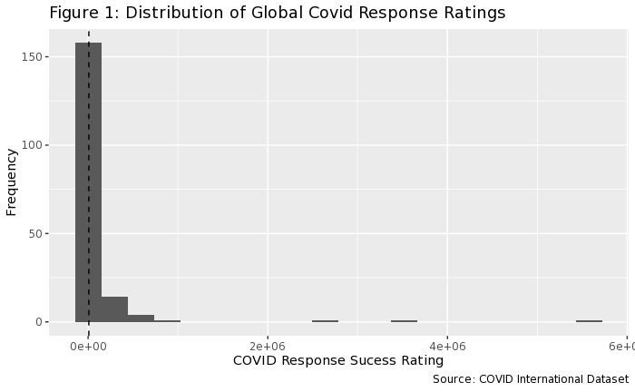

```r
complete_cov_data %>%
  ggplot(mapping=aes(x=response_sucess_lev))+
    geom_histogram(bins=20)+
    geom_vline(aes(xintercept=median(response_sucess_lev,na.rm=TRUE)),color="black",linetype="dashed")+
    labs(title="Figure 1: Distribution of Global Covid Response Ratings",
         caption="Source: COVID International Dataset",
         x="COVID Response Sucess Rating",
         y="Frequency")
```

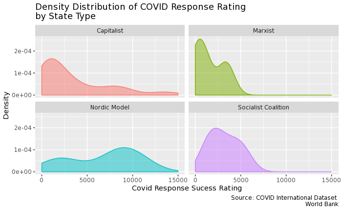

```r
complete_cov_data%>%
  ggplot(mapping=aes(x=response_sucess_lev,facet=factor(state_type),fill=factor(state_type)))+
  geom_density(alpha=.5,aes(color=factor(state_type)))+
  guides(fill=FALSE,color=FALSE)+
  labs(title="Density Distribution of COVID Response Rating \nby State Type",
       caption="Source: COVID International Dataset \nWorld Bank",
       fill="State Type",
       x="Covid Response Sucess Rating",
       y="Density")+
  scale_x_continuous(limits=c(0,15000))+
  facet_wrap(~state_type)
```

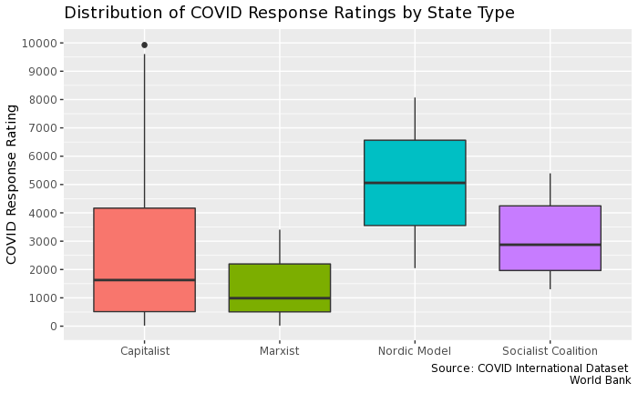

```r
complete_cov_data%>%
  ggplot(mapping=aes(x=state_type,y=response_sucess_lev,fill=state_type))+
  geom_boxplot()+
  guides(fill=FALSE,color=FALSE)+
  labs(title="Distribution of COVID Response Ratings by State Type",
       caption="Source: COVID International Dataset \nWorld Bank",
       x=NULL,
       y="COVID Response Rating")+
  scale_y_continuous(limits=c(0,10000),breaks=c(0,1000,2000,3000,4000,5000,6000,7000,8000,9000,10000))+
  scale_fill_discrete(name="State Type")
```

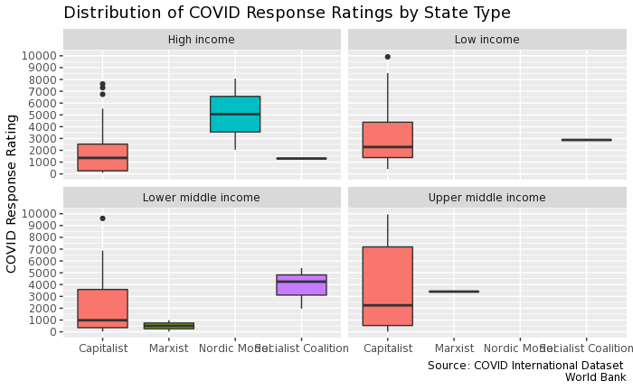

```r
complete_cov_data %>%
  filter(!is.na(IncomeGroup)) %>%
  ggplot(mapping=aes(x=state_type,y=response_sucess_lev,fill=state_type))+
  geom_boxplot()+
  guides(fill=FALSE,color=FALSE)+
  labs(title="Distribution of COVID Response Ratings by State Type",
       caption="Source: COVID International Dataset \nWorld Bank",
       x=NULL,
       y="COVID Response Rating")+
  facet_wrap(~IncomeGroup)+
  scale_y_continuous(limits=c(0,10000),breaks=c(0,1000,2000,3000,4000,5000,6000,7000,8000,9000,10000))+
  scale_fill_discrete(name="State Type")
```

#### For capitalist States

```r
median(capitalist_govs$response_sucess_lev,na.rm=TRUE)
```

```
[1] 8108.771
```

```r
sd(capitalist_govs$response_sucess_lev,na.rm=TRUE)
```

```
[1] 564849.8
```

```r
range(capitalist_govs$response_sucess_lev,na.rm=TRUE)
```

```
[1] 1.927102e+01 5.573396e+06
```

```r
nrow(capitalist_govs)
```

```
[1] 192
```

#### For Socialist Coalition Govs

```r
median(socialist_govs$response_sucess_lev,na.rm=TRUE)
```

```
[1] 26768.5
```

```r
sd(socialist_govs$response_sucess_lev,na.rm=TRUE)
```

```
[1] 130061.4
```

```r
range(socialist_govs$response_sucess_lev,na.rm=TRUE)
```

```
[1]   1303.25 371464.74
```

```r
nrow(socialist_govs)
```

```
[1] 11
```

#### For Nordic nations

```r
median(nordic_model$response_sucess_lev,na.rm=TRUE)
```

```
[1] 10119.36
```

```r
sd(nordic_model$response_sucess_lev,na.rm=TRUE)
```

```
[1] 36575.45
```

```r
range(nordic_model$response_sucess_lev,na.rm=TRUE)
```

```
[1]  2047.082 90116.297
```

```r
nrow(nordic_model)
```

```
[1] 5
```

#### For Marxist States

```r
median(marxist$response_sucess_lev,na.rm=TRUE)
```

```
[1] 2196.986
```

```r
sd(marxist$response_sucess_lev,na.rm=TRUE)
```

```
[1] 46325.37
```

```r
range(marxist$response_sucess_lev,na.rm=TRUE)
```

```
[1]    20.02001 94078.29540
```

```r
nrow(marxist)
```

```
[1] 4
```

#### For world data

```r
median(complete_cov_data$response_sucess_lev,na.rm = TRUE)
```

```
[1] 8108.771
```

```r
sd(complete_cov_data$response_sucess_lev,na.rm = TRUE)
```

```
[1] 533988.8
```

```r
range(complete_cov_data$response_sucess_lev,na.rm = TRUE)
```

```
[1] 1.927102e+01 5.573396e+06
```

```r
nrow(complete_cov_data)
```

```
[1] 212
```

#### Central Tendancy, Range, Standard Dev, and Distribution of State Types:

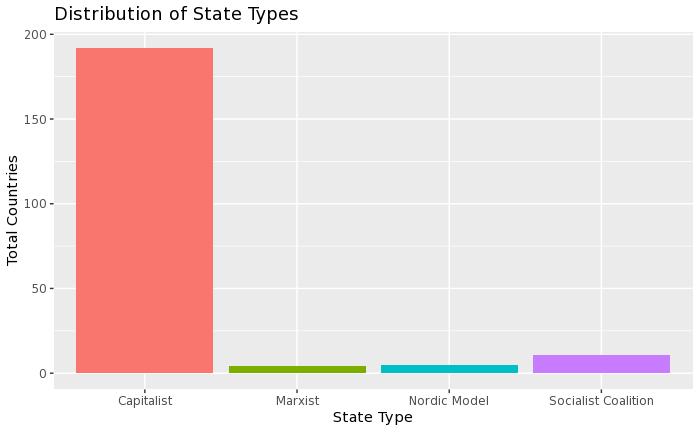

```r
complete_cov_data %>%
  ggplot(mapping=aes(x=state_type,fill=state_type))+
    geom_bar()+
    guides(fill=FALSE,color=FALSE)+
    labs(title="Distribution of State Types",
         x="State Type",
         y="Total Countries")+
  scale_fill_discrete(name="State Type")
```

### Analysis of the Relationship Between Variables and Results

#### Preliminary Analysis of the Variables

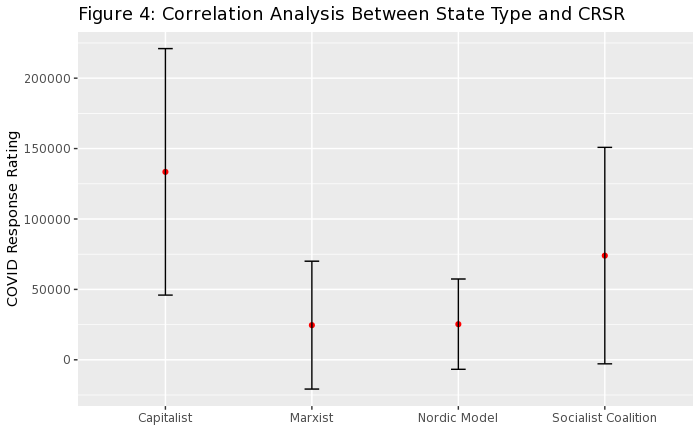

```r
complete_cov_data%>%
  filter(!is.na(state_type) & !is.na(response_sucess_lev))%>%
  group_by(state_type)%>%
  summarize(mean=mean(response_sucess_lev, na.rm=TRUE), n=n(), sd=sd(response_sucess_lev, na.rm=TRUE))%>%
  mutate(margin=1.96*sd/sqrt(n)) %>%
ggplot(mapping=aes(y=mean, x=factor(state_type))) +
  geom_point(color="red") +
  geom_errorbar(aes(ymin=mean-margin, ymax=mean+margin), width=.1)+
  labs(title="Figure 4: Correlation Analysis Between State Type and CRSR",
       x=NULL,
       y= "COVID Response Rating")
```

#### Multiple Regression Analysis of the Variables

A linear regression model was conducted to determine the relationship between the variables. Overall, there was no statistically significant relationship found between State Type and CRSRs, although all leftist states types did create a decrease of CRSR.

The following Variables were utilized as controls:

- **Economic Development Level:** Countries with a higher income level naturally would have access to better resources and be better equipped to fight the pandemic.
- **Population Density:** Countries with more persons closely packed could have a higher viral spread.
- **Democracy Rating:** A lower democracy index rating might correlate to the citizens of the nation having restricted lives anyways, which could lower COVID cases.
- **Stringency of Response:** Nations with tighter lockdowns and more closures of public spaces may have lower transmission of COVID outside their socialized medicine and economic apparatus.

```r
multi_reg1 <- lm(response_sucess_lev ~ state_type + IncomeGroup+ pop_density + response + fh_polity2, data=complete_cov_data)
summary(multi_reg1)
```

```
Call:
lm(formula = response_sucess_lev ~ state_type + IncomeGroup +
    pop_density + response + fh_polity2, data = complete_cov_data)

Residuals:
    Min      1Q  Median      3Q     Max
-307441 -188811  -75190   18731 5324685

Coefficients:
                                 Estimate Std. Error t value Pr(>|t|)
(Intercept)                     143099.35  262055.46   0.546    0.586
state_typeMarxist               -59724.71  317069.28  -0.188    0.851
state_typeNordic Model         -250746.71  313835.20  -0.799    0.426
state_typeSocialist Coalition   -83740.08  187390.96  -0.447    0.656
IncomeGroupLow income          -104565.04  175091.15  -0.597    0.551
IncomeGroupLower middle income  -31894.70  143566.27  -0.222    0.825
IncomeGroupUpper middle income   94818.39  147963.89   0.641    0.523
pop_density                        -10.64      74.21  -0.143    0.886
response                         -1848.94    3298.33  -0.561    0.576
fh_polity2                       20650.32   19579.55   1.055    0.293

Residual standard error: 588100 on 141 degrees of freedom
  (61 observations deleted due to missingness)
Multiple R-squared:  0.03485,   Adjusted R-squared:  -0.02675
F-statistic: 0.5658 on 9 and 141 DF,  p-value: 0.8233
```

```r
library(stargazer)
stargazer(multi_reg1,
          type='text',
          title = "Multi Regression of CRSR Sucess Ratings",
          dep.var.caption = "COVID Response Sucess Rating",
          covariate.labels = c("Marxist State","Nordic Model","Socialist Coalition","Low Income","Lower Middle Income","Upper Middle Income","Population Density","Response Stringency","Democracy Rating","Intercept"))
```

```
Multi Regression of CRSR Sucess Ratings
================================================
                    COVID Response Sucess Rating
                    ----------------------------
                        response_sucess_lev
------------------------------------------------
Marxist State               -59,724.710
                           (317,069.300)

Nordic Model                -250,746.700
                           (313,835.200)

Socialist Coalition         -83,740.080
                           (187,391.000)

Low Income                  -104,565.000
                           (175,091.100)

Lower Middle Income         -31,894.700
                           (143,566.300)

Upper Middle Income          94,818.390
                           (147,963.900)

Population Density            -10.637
                              (74.206)

Response Stringency          -1,848.941
                            (3,298.328)

Democracy Rating             20,650.320
                            (19,579.550)

Intercept                   143,099.400
                           (262,055.500)

------------------------------------------------
Observations                    151
R2                             0.035
Adjusted R2                    -0.027
Residual Std. Error    588,142.700 (df = 141)
F Statistic             0.566 (df = 9; 141)
================================================
Note:                *p<0.1; **p<0.05; ***p<0.01
```

#### Concluding Remarks

Based on the data analysis presented herein, it can be said with some degree of certainty that the socioeconomic organization of a state does not affect it’s ability to better combat the pandemic. As shown by the predictive modeling, the average CRSR for Socialist Coalition States, Marxist States, and Nordic Model States were all lower than the CRSR for capitalist states, which translates to a better response as the CRSR is a combined measure that denotes smaller deaths, infection count, mortality rate due to COVID, and smaller infection rate. Alongside this was possible predictive evidence to suggest that nations with less traditional liberal democratic structures might be better equipped at dealing with the pandemic. This could possibly be due in part to the social ostracization and collectivist mindset usually incorporated into authoritarian regimes.

Furthermore, there is the possibiity that the study was constrained by sources of error and limitations. The model itself does not have a very high level of confidence (low $R^2$ value), thus leading to the possibility that the relation we are seeing is indeed real, but requires further analysis of possible confounding and control variables in order to determine if this prediction is in fact real. Moreover, due to the possible evidence of the suppression of counting and data collection in places such as the United States or China, there is a chance that the numbers presented are not correct and thus prevent a proper relationship. It is possible that there are cultural aspects and social aspects, such as social traditions that may not be accounted for or could better predict how leftist policies affect COVID., for example, the Confucianist traditions of China and Vietnam and the cultural collectivism inherent in Nordic and Viking culture might be a confounding variable. Another possible issue is that the categorization for State Type, specifically the Socialist Coalition category, was assigned based on personal knowledge and research. Furthermore, parties with officially leftwing ideas may not always enact the socialistic policies shown in past literature to better deal with pandemics (see Sweden and Spain’s comparatively center to center-right wing responses to COVID).